# Customizing an MCMC

enviBayes 2021 tutorial

NIMBLE Development Team

# Customizing samplers: examining the defaults

One of NIMBLE’s most important features is that users can easily modify the MCMC algorithm used for their model. The easiest thing to do is to start with NIMBLE’s default MCMC and then make modifications.

```r
littersConf$printSamplers()
```

```
## [1]  RW sampler: a[1]
## [2]  RW sampler: a[2]
## [3]  RW sampler: b[1]
## [4]  RW sampler: b[2]
## [5]  conjugate_dbeta_dbin_identity sampler: p[1, 1]
## [6]  conjugate_dbeta_dbin_identity sampler: p[1, 2]
## [7]  conjugate_dbeta_dbin_identity sampler: p[1, 3]
## [8]  conjugate_dbeta_dbin_identity sampler: p[1, 4]
## [9]  conjugate_dbeta_dbin_identity sampler: p[1, 5]
## [10] conjugate_dbeta_dbin_identity sampler: p[1, 6]
## [11] conjugate_dbeta_dbin_identity sampler: p[1, 7]
## [12] conjugate_dbeta_dbin_identity sampler: p[1, 8]
## [13] conjugate_dbeta_dbin_identity sampler: p[1, 9]
## [14] conjugate_dbeta_dbin_identity sampler: p[1, 10]
## [15] conjugate_dbeta_dbin_identity sampler: p[1, 11]
```

[output cut: 21 more lines]

# Customizing samplers: modifying the samplers

Let’s try using slice samplers (these are used by default much more heavily in JAGS than in NIMBLE).

```r
hypers <- c('a[1]', 'b[1]', 'a[2]', 'b[2]')
for(h in hypers) {
      littersConf$removeSamplers(h)
      littersConf$addSampler(target = h, type = 'slice')
}
littersConf$printSamplers()
```

```
## [1]  conjugate_dbeta_dbin_identity sampler: p[1, 1]
## [2]  conjugate_dbeta_dbin_identity sampler: p[1, 2]
## [3]  conjugate_dbeta_dbin_identity sampler: p[1, 3]
## [4]  conjugate_dbeta_dbin_identity sampler: p[1, 4]
## [5]  conjugate_dbeta_dbin_identity sampler: p[1, 5]
## [6]  conjugate_dbeta_dbin_identity sampler: p[1, 6]
## [7]  conjugate_dbeta_dbin_identity sampler: p[1, 7]
## [8]  conjugate_dbeta_dbin_identity sampler: p[1, 8]
## [9]  conjugate_dbeta_dbin_identity sampler: p[1, 9]
## [10] conjugate_dbeta_dbin_identity sampler: p[1, 10]
## [11] conjugate_dbeta_dbin_identity sampler: p[1, 11]
## [12] conjugate_dbeta_dbin_identity sampler: p[1, 12]
## [13] conjugate_dbeta_dbin_identity sampler: p[1, 13]
## [14] conjugate_dbeta_dbin_identity sampler: p[1, 14]
## [15] conjugate_dbeta_dbin_identity sampler: p[1, 15]
```

[output cut: 21 more lines]

```r
littersMCMC <- buildMCMC(littersConf)
## We need 'resetFunctions' because we are rebuilding the MCMC for an existing model for
## which we've already done some compilation.
cLittersMCMC <- compileNimble(littersMCMC, project = littersModel,
   resetFunctions = TRUE)
```

```
## Compiling
##   [Note] This may take a minute.
##   [Note] Use 'showCompilerOutput = TRUE' to see C++ compilation details.
```

```r
niter <- 5000
nburn <- 1000

set.seed(1)
samplesSlice <- runMCMC(cLittersMCMC, niter = niter, nburnin = nburn,
             inits = littersInits, nchains = 1, samplesAsCodaMCMC = TRUE)
```

```
## running chain 1...
```

```
## |-------------|-------------|-------------|-------------|
## |-------------------------------------------------------|
```

# Customizing samplers: Initial results

We can look at diagnostics and see if the change in samplers had an effect. Here, simply changing the univariate samplers doesn’t have much effect, because the real story is in the posterior correlation between `a[i]` and `b[i]`. But in other cases it can make a bigger difference.

Caveat: the real question is the effective sample size per unit of computation time (each slice sampler iteration is much slower than each Metropolis iteration), but we don’t assess that at the moment.

```r
effectiveSize(samplesSlice)
```

```
##        a[1]        a[2]        b[1]        b[2]     p[1, 1]     p[2, 1]
##    7.191837  151.663356    6.188247  154.552882   20.128276 1085.328914
##     p[1, 2]     p[2, 2]     p[1, 3]     p[2, 3]     p[1, 4]     p[2, 4]
##   20.238555  601.112686   20.063697  931.421591   21.024985 1145.733949
##     p[1, 5]     p[2, 5]     p[1, 6]     p[2, 6]     p[1, 7]     p[2, 7]
##   22.420767 3652.783783   19.611488 2837.102882   20.773575 2866.668779
##     p[1, 8]     p[2, 8]     p[1, 9]     p[2, 9]    p[1, 10]    p[2, 10]
##   20.998934 3438.916187   19.827334 3494.220502   21.867572 3785.298842
##    p[1, 11]    p[2, 11]    p[1, 12]    p[2, 12]    p[1, 13]    p[2, 13]
##   21.243242 4000.000000   19.291943 2276.795580   19.951566 1581.485675
##    p[1, 14]    p[2, 14]    p[1, 15]    p[2, 15]    p[1, 16]    p[2, 16]
##   21.350778 2133.962392   22.320359 1059.973627   22.602981  529.167894
```

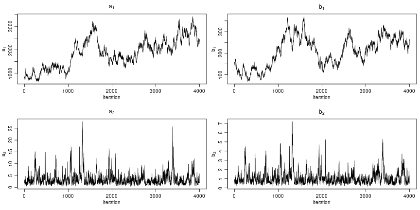

```r
makePlot(samplesSlice)
```

# Blocking parameters

Often a key factor that reduces MCMC performance is dependence between parameters that limits the ability of univariate samplers to move very far. A standard strategy is to sample correlated parameters in blocks. Unlike many other MCMC engines, NIMBLE makes it easy for users to choose what parameters to sample in blocks.

We’ll try that here for `a` and `b`.

```r
niter <- 5000
nburn <- 1000

littersConf <- configureMCMC(littersModel, monitors = c('a', 'b', 'p'))
```

```
## ===== Monitors =====
## thin = 1: a, b, p
## ===== Samplers =====
## RW sampler (4)
##   - a[]  (2 elements)
##   - b[]  (2 elements)
## conjugate sampler (32)
##   - p[]  (32 elements)
```

```r
hypers <- littersModel$getNodeNames(topOnly = TRUE)
print(hypers)
```

```
## [1] "a[1]" "a[2]" "b[1]" "b[2]"
```

```r
for(h in hypers) {
      littersConf$removeSamplers(h)
}
littersConf$addSampler(target = c('a[1]','b[1]'), type = 'RW_block',
                              control = list(adaptInterval = 20, adaptFactorExponent = 0.25))
```

```
## Note: Assigning an RW_block sampler to nodes with very different scales can result in low MCMC efficiency.  If all nodes assigned to RW_block are not on a similar scale, we recommend providing an informed value for the "propCov" control list argument, or using the AFSS sampler instead.
```

```r
littersConf$addSampler(target = c('a[2]','b[2]'), type = 'RW_block',
                              control = list(adaptInterval = 20, adaptFactorExponent = 0.25))
```

```
## Note: Assigning an RW_block sampler to nodes with very different scales can result in low MCMC efficiency.  If all nodes assigned to RW_block are not on a similar scale, we recommend providing an informed value for the "propCov" control list argument, or using the AFSS sampler instead.
```

```r
littersMCMC <- buildMCMC(littersConf)
cLittersMCMC <- compileNimble(littersMCMC, project = littersModel, resetFunctions = TRUE)
```

```
## Compiling
##   [Note] This may take a minute.
##   [Note] Use 'showCompilerOutput = TRUE' to see C++ compilation details.
```

```r
set.seed(1)
samplesBlock <- runMCMC(cLittersMCMC, niter = niter, nburnin = nburn,
             inits = littersInits, nchains = 1, samplesAsCodaMCMC = TRUE)
```

```
## running chain 1...
```

```
## |-------------|-------------|-------------|-------------|
## |-------------------------------------------------------|
```

```r
effectiveSize(samplesBlock)
```

```
##       a[1]       a[2]       b[1]       b[2]    p[1, 1]    p[2, 1]    p[1, 2]
##   33.86632  101.41337   35.23315  103.57563   20.82346 1039.82103   19.76178
##    p[2, 2]    p[1, 3]    p[2, 3]    p[1, 4]    p[2, 4]    p[1, 5]    p[2, 5]
##  815.63917   18.03884  892.16874   18.69189 1094.87731   21.98678 2161.73220
##    p[1, 6]    p[2, 6]    p[1, 7]    p[2, 7]    p[1, 8]    p[2, 8]    p[1, 9]
##   19.11531 1975.62110   16.10892 3747.76019   16.33471 2442.87438   18.38433
##    p[2, 9]   p[1, 10]   p[2, 10]   p[1, 11]   p[2, 11]   p[1, 12]   p[2, 12]
## 2613.30847   24.16714 3746.00759   18.48966 3516.05994   22.20508 2128.54971
##   p[1, 13]   p[2, 13]   p[1, 14]   p[2, 14]   p[1, 15]   p[2, 15]   p[1, 16]
##   20.78863 2135.95273   17.32952 1967.11261   17.11228  989.83726   22.20015
##   p[2, 16]
##  369.24043
```

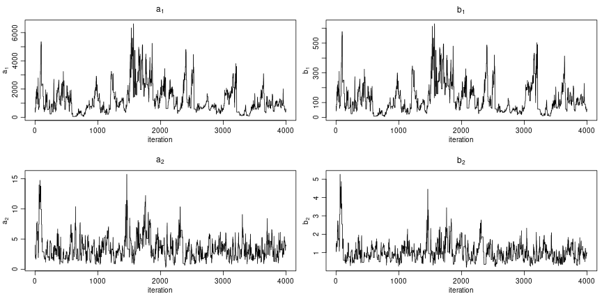

```r
makePlot(samplesBlock)
```

The block sampler seems to help some, but hopefully we can do better. Often block sampling gives bigger improvements, but it can be sensitive to how it’s configured/initialized.